# Séismes au Japon : de la routine sismique à Tohoku

Une exploration des données USGS (2000-2024)

Stéphane Kosmala

2026-08-04

## Introduction

Le Japon est l’un des pays les plus sismiquement actifs au monde, situé sur la “ceinture de feu” du Pacifique, à la jonction de plusieurs plaques tectoniques. Ce rapport explore 24 ans de données sismiques (2000-2024) issues du catalogue de l’USGS (US Geological Survey), en se concentrant sur les séismes de magnitude 4.5 et plus.

L’objectif : comprendre la structure “normale” de l’activité sismique japonaise, puis zoomer sur l’événement qui a marqué la période — le séisme de Tohoku du 11 mars 2011 pour voir comment les données racontent son impact.

**Questions posées à ces données :**

- À quoi ressemble la distribution habituelle des séismes (magnitude, profondeur) ?
- L’activité sismique est-elle stable dans le temps, ou marquée par des événements exceptionnels ?
- Comment se comportent les répliques après un séisme majeur ?

```r
seismes <- read_csv("data/raw/seismes_japon.csv")
```

## 1. Aperçu et qualité des données

Le jeu de données couvre 15190 séismes, sur la période allant de 2000-01-03 à 2024-12-30.

```r
# Valeurs manquantes
na_count <- sum(colSums(is.na(seismes)))

# Doublons
doublons <- sum(duplicated(seismes$id))

# Valeurs aberrantes
mag_aberrantes <- seismes %>% filter(magnitude < 0 | magnitude > 10) %>% nrow()
coord_aberrantes <- seismes %>%
  filter(latitude < 24 | latitude > 46 | longitude < 122 | longitude > 146) %>%
  nrow()
profondeur_aberrante <- seismes %>% filter(profondeur_km < 0) %>% nrow()
```

Contrôles effectués : 0 valeurs manquantes, 0 doublons, 0 magnitudes hors plage plausible, 0 coordonnées hors de la zone géographique attendue, et 0 profondeurs négatives. Le jeu de données est propre et ne nécessite pas de nettoyage supplémentaire.

## 2. La routine sismique : distributions générales

### Magnitude

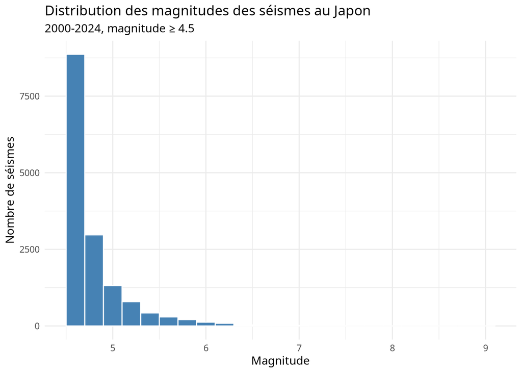

```r
ggplot(seismes, aes(x = magnitude)) +
  geom_histogram(binwidth = 0.2, fill = "steelblue", color = "white") +
  labs(title = "Distribution des magnitudes des séismes au Japon",
       subtitle = "2000-2024, magnitude ≥ 4.5",
       x = "Magnitude", y = "Nombre de séismes") +
  theme_minimal()
```

La distribution suit la forme attendue par la loi de Gutenberg-Richter : une décroissance quasi exponentielle où les séismes modérés (proches du seuil de 4.5) sont largement majoritaires, et les séismes de forte magnitude deviennent rapidement rares. C’est une régularité observée partout dans le monde, et le Japon ne fait pas exception malgré son niveau d’activité élevé.

### Profondeur

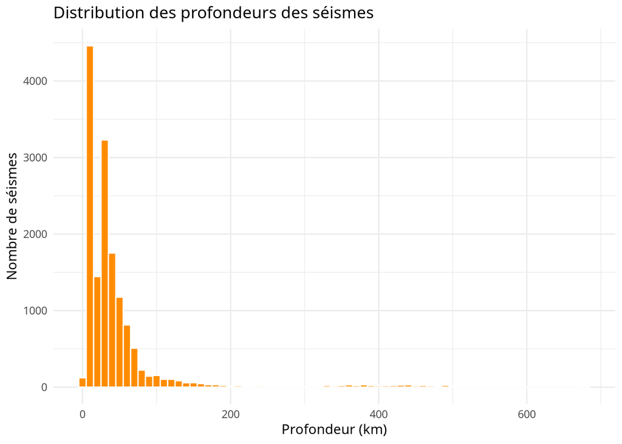

```r
ggplot(seismes, aes(x = profondeur_km)) +
  geom_histogram(binwidth = 10, fill = "darkorange", color = "white") +
  labs(title = "Distribution des profondeurs des séismes",
       x = "Profondeur (km)", y = "Nombre de séismes") +
  theme_minimal()
```

### Profondeur et magnitude sont-elles liées ?

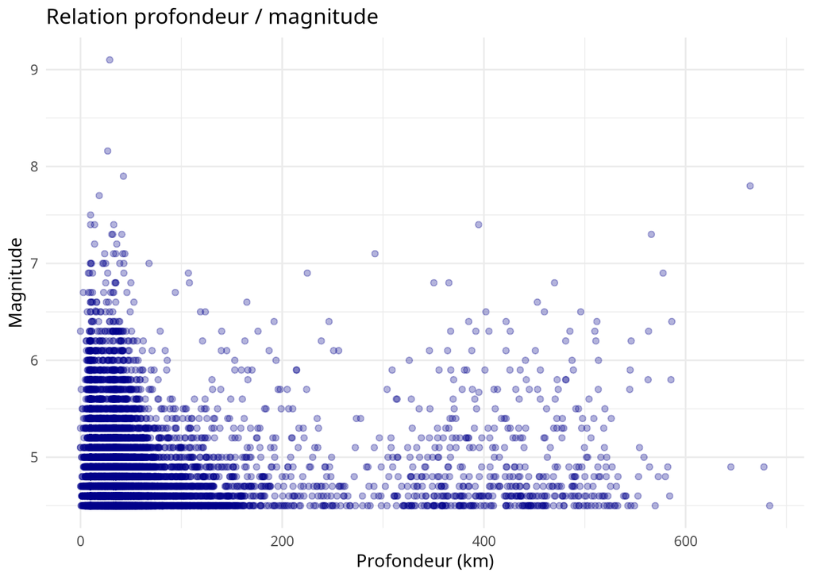

```r
ggplot(seismes, aes(x = profondeur_km, y = magnitude)) +
  geom_point(alpha = 0.3, color = "darkblue") +
  labs(title = "Relation profondeur / magnitude",
       x = "Profondeur (km)", y = "Magnitude") +
  theme_minimal()
```

Le nuage de points ne montre pas de relation linéaire nette : les séismes les plus forts se produisent aussi bien en surface qu’en profondeur. Cela reflète la diversité des mécanismes tectoniques actifs au Japon (subduction en mer, failles crustales sur terre).

## 3. Une activité stable, ou marquée par des ruptures ?

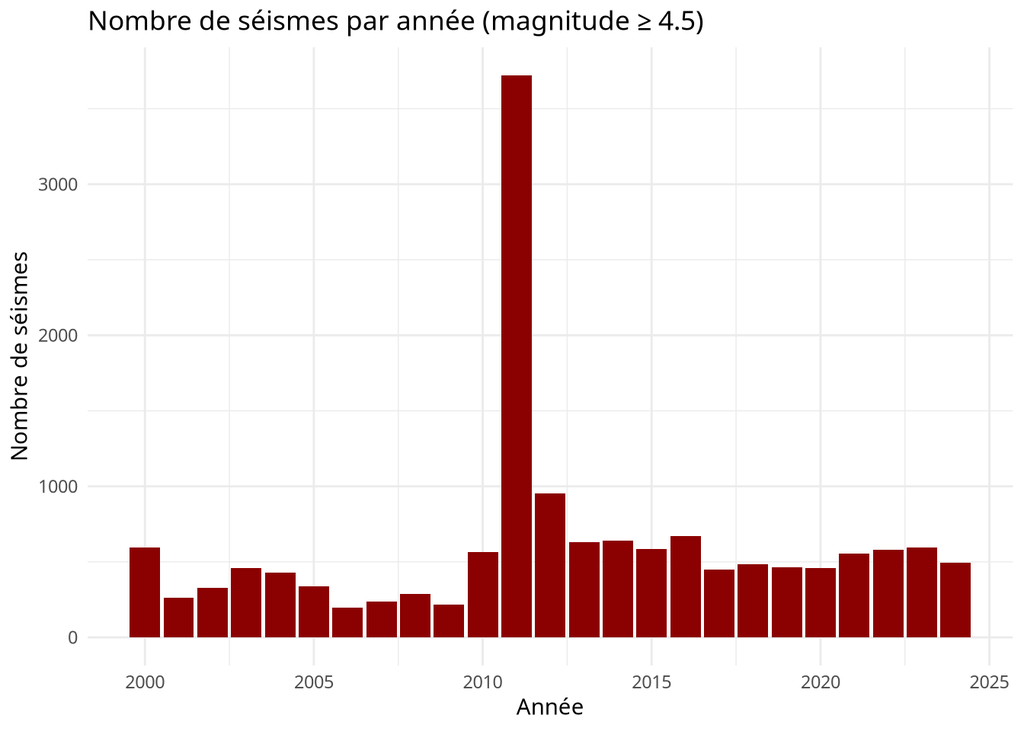

```r
seismes_par_annee <- seismes %>%
  mutate(annee = year(temps)) %>%
  count(annee)

ggplot(seismes_par_annee, aes(x = annee, y = n)) +
  geom_col(fill = "darkred") +
  labs(title = "Nombre de séismes par année (magnitude ≥ 4.5)",
       x = "Année", y = "Nombre de séismes") +
  theme_minimal()
```

Un pic massif se détache immédiatement : **2011**. Deux hypothèses peuvent l’expliquer : soit un événement sismique exceptionnel, soit un artefact technique (par exemple une amélioration du réseau de détection à cette période). Si c’était un artefact de détection, on s’attendrait à une hausse progressive sur plusieurs années plutôt qu’un pic isolé sur une seule année — ce n’est pas le cas ici, ce qui oriente vers un véritable événement sismique plutôt qu’un biais de mesure.

## 4. Zoom sur 2011 : le séisme de Tohoku

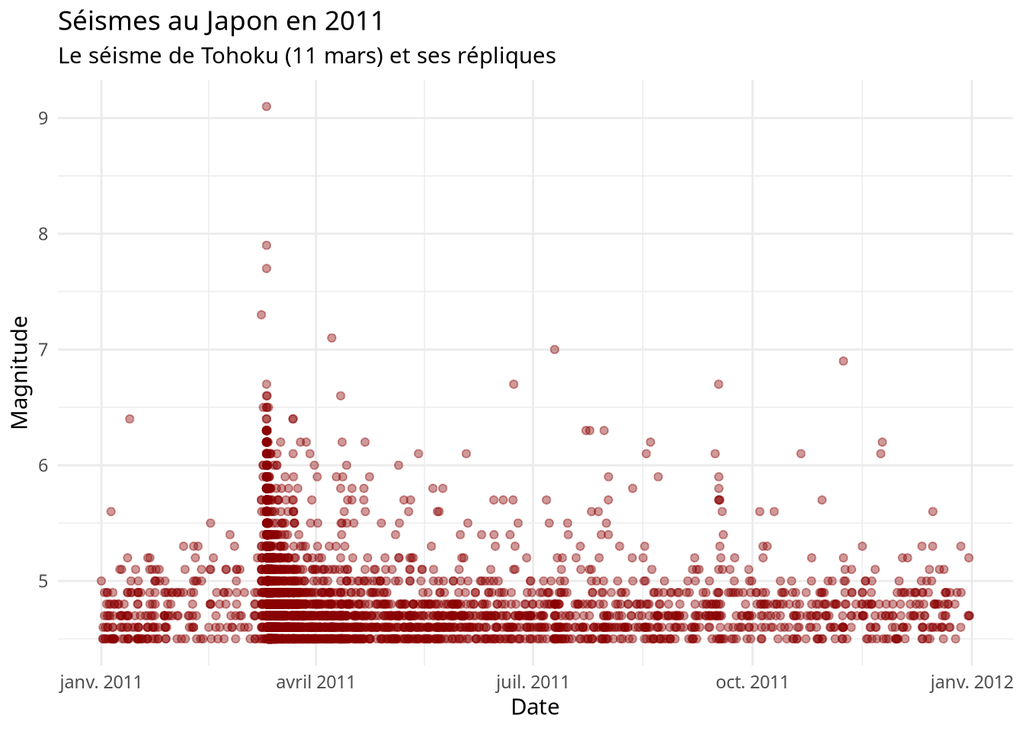

```r
seismes %>%
  filter(year(temps) == 2011) %>%
  ggplot(aes(x = temps, y = magnitude)) +
  geom_point(alpha = 0.4, color = "darkred") +
  labs(title = "Séismes au Japon en 2011",
       subtitle = "Le séisme de Tohoku (11 mars) et ses répliques",
       x = "Date", y = "Magnitude") +
  theme_minimal()
```

L’explosion du nombre de points à partir de mars confirme l’hypothèse : c’est bien la séquence de répliques de Tohoku qui explique le pic annuel observé précédemment.

### La décroissance des répliques : une loi physique observable

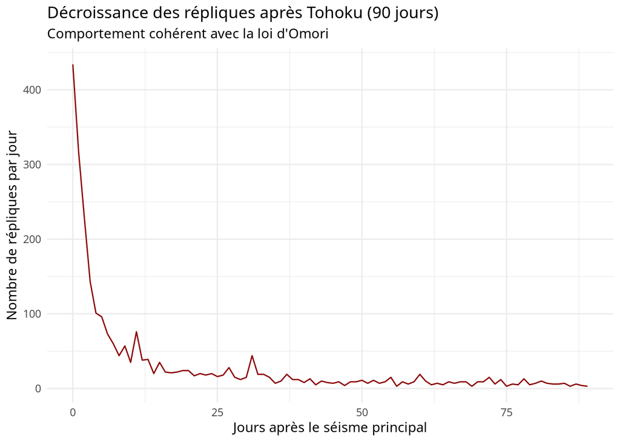

```r
tohoku_date <- as_datetime("2011-03-11")

repliques <- seismes %>%
  filter(temps >= tohoku_date, temps <= tohoku_date + days(90)) %>%
  mutate(jours_apres = as.numeric(difftime(temps, tohoku_date, units = "days")))

repliques %>%
  count(jour = floor(jours_apres)) %>%
  ggplot(aes(x = jour, y = n)) +
  geom_line(color = "darkred") +
  labs(title = "Décroissance des répliques après Tohoku (90 jours)",
       subtitle = "Comportement cohérent avec la loi d'Omori",
       x = "Jours après le séisme principal", y = "Nombre de répliques par jour") +
  theme_minimal()
```

La courbe montre une chute rapide du nombre de répliques dans les premiers jours, suivie d’une stabilisation progressive. Ce comportement correspond à la **loi d’Omori**, une régularité empirique bien documentée en sismologie : le taux de répliques après un séisme principal décroît approximativement en 1/t. Le voir apparaître aussi nettement sur des données réelles, sans modélisation complexe, est une belle validation empirique d’une loi physique connue.

### Où se concentrent les répliques ?

```r
repliques %>%
  leaflet() %>%
  addTiles() %>%
  addCircleMarkers(
    lng = ~longitude, lat = ~latitude,
    radius = ~magnitude,
    color = "darkred", fillOpacity = 0.4,
    popup = ~paste("Magnitude:", magnitude, "<br>Date:", temps)
  ) %>%
  setView(lng = 142, lat = 38, zoom = 5)
```

[interactive chart not shown]

Les répliques se concentrent le long de la zone de subduction au large de la côte Tohoku, là où la plaque Pacifique plonge sous la plaque nord-américaine cohérent avec le mécanisme physique du séisme principal.

## Conclusion

Cette exploration révèle deux niveaux de lecture dans l’activité sismique japonaise :

- une **routine** régulière et prévisible (distribution des magnitudes conforme à la loi de Gutenberg-Richter, activité globalement stable d’une année sur l’autre)
- une **rupture** ponctuelle mais majeure en 2011, dont la signature (décroissance des répliques, concentration géographique) suit des lois physiques bien connues en sismologie

**Limites de l’analyse** : le seuil de magnitude ≥ 4.5 exclut les nombreux petits séismes, qui représentent la majorité de l’activité sismique réelle au Japon. La bounding box géographique utilisée pour la requête inclut aussi des zones maritimes voisines (Russie, péninsule coréenne), ce qui peut légèrement gonfler le compte pour les zones frontalières.